# MDTs_tutorial

The MDTs package is a powerful tool for analyzing and visualizing multidimensional traits in plants. It provides a comprehensive set of functions for various trait-based ecological analyses, including CSR strategy analysis, LHS strategy analysis, niche periodicity table analysis, and trait network analysis. This vignette will guide you through the installation process and demonstrate the main functions of the package using example datasets.

## Installation

You can install the MDTs package from GitHub using the following commands:

```r
# Install devtools if not already installed
if (!requireNamespace("devtools", quietly = TRUE)) {
  install.packages("devtools")
}

# Install MDTs from GitHub
devtools::install_github("biodiversity-monitoring/MDTs")
```

[output not shown]

[output not shown]

[output not shown]

## Main Functions

[output not shown]

### Example Datasets

The MDTs package includes two example datasets: PFF and WH. Let’s load the package and examine these datasets:

```r
library(MDTs)
data(PFF)
data(WH)

# View the structure of the datasets
str(PFF)
```

```
## 'data.frame':    133 obs. of  20 variables:
##  $ family    : chr  "Asteraceae" "Asteraceae" "Poaceae" "Asteraceae" ...
##  $ species   : chr  "Achillea millefolium" "Agoseris glauca" "Agropyron desertorum" "Ambrosia psilostachya" ...
##  $ Height    : int  14 12 26 44 1 2 1 8 15 7 ...
##  $ Leaf_area : num  240 520 290 490 51 66 30 32 40 20 ...
##  $ LDMC      : int  27 17 42 20 14 27 29 27 15 43 ...
##  $ SLA       : int  8 20 9 16 31 13 19 13 22 7 ...
##  $ SRL       : int  35 56 99 73 80 27 30 50 29 51 ...
##  $ SeedMass  : num  0.14 2.53 0.388 5.896 0.128 ...
##  $ FltDate   : int  197 213 198 243 182 182 182 182 197 182 ...
##  $ FltDur    : int  152 183 91 122 182 122 122 182 152 182 ...
##  $ k_value   : num  1.7 1.1 NA 2.23 NA 0.54 0.65 1.04 1.33 0.58 ...
##  $ Leaf_Cmass: num  41.2 42.6 41.5 38.4 40.8 ...
##  $ Leaf_Nmass: num  1.92 1.72 2.32 2.32 1.95 1.53 1.59 1.74 1.8 0.99 ...
##  $ Leaf_CN   : int  22 25 18 17 22 30 26 25 25 41 ...
##  $ Leaf_Pmass: num  0.36 0.39 0.06 0.25 0.29 0.18 0.17 0.13 0.13 0.06 ...
##  $ Leaf_NP   : int  6 4 52 14 7 9 10 14 16 18 ...
##  $ Leaf_CP   : int  114 109 1021 224 131 252 266 341 387 759 ...
##  $ Root_Cmass: num  41 45.9 41.5 35.7 46.5 ...
##  $ Root_Nmass: num  0.48 0.89 1.61 1.29 1.23 0.55 0.41 0.96 0.93 0.66 ...
##  $ Root_CN   : int  85 52 26 28 38 65 101 47 47 56 ...
```

```r
str(WH)
```

```
## 'data.frame':    46 obs. of  23 variables:
##  $ Species: chr  "Acorus calamus" "Alisma triviale" "Butomus umbellatus " "Calla palustris" ...
##  $ species: chr  "AcoCal" "AliTri" "ButUmb" "CalPal" ...
##  $ ROH    : chr  "P" "S" "S" "S" ...
##  $ Height : num  67.4 33.5 52.5 18.8 42.4 64 71.8 38.5 54.4 57 ...
##  $ ShDM   : num  5377 2247 706 279 550 ...
##  $ Depth  : num  32.1 47.5 34.8 36.5 27.4 25.4 28.5 17.8 36.2 33 ...
##  $ RBD    : num  7.1 1.96 4.19 1.16 5.2 ...
##  $ RBL    : num  20.1 2.65 6.55 1.72 2.07 ...
##  $ RD_AR  : num  2.093 1.045 1.558 0.947 0.788 ...
##  $ RD_LR  : num  0.211 0.157 0.152 0.233 0.138 0.167 0.14 0.148 0.164 0.222 ...
##  $ RDMC_AR: num  0.14 0.061 0.048 0.045 0.189 0.174 0.163 0.154 0.189 0.147 ...
##  $ RDMC_LR: num  0.098 0.103 0.083 0.051 0.153 0.144 0.116 0.12 0.144 0.113 ...
##  $ SRL_AR : num  3.74 55.98 19.88 38.89 20.95 ...
##  $ SRL_LR : num  152 469 438 475 244 ...
##  $ RP_AR  : num  0.473 0.283 0.4 0.315 0.472 0.273 0.374 0.285 0.504 0.533 ...
##  $ RP_LR  : num  0.133 0.076 0.092 0.144 0.107 0.061 0.126 0.155 0.127 0.192 ...
##  $ LT     : num  3.57 0.438 3.75 0.46 0.285 0.373 1.5 0.3 1.8 0.91 ...
##  $ LDMC   : num  0.19 0.135 0.151 0.139 0.288 0.201 0.297 0.361 0.358 0.316 ...
##  $ SLA    : num  9.4 14.9 9.15 25.3 24.45 ...
##  $ LP     : num  0.581 0.277 0.563 0.457 0.237 0.266 0.35 0.228 0.529 0.087 ...
##  $ RhDMC  : num  0.368 0.291 0.316 0.21 0.295 NA 0.169 0.285 0.197 0.162 ...
##  $ RhP    : num  0.218 NA 0.145 0.431 0.409 NA 0.414 0.334 0.331 0.27 ...
##  $ LSI    : num  0.8 1 NA 0.87 NA NA 0.5 NA 0.37 0.33 ...
```

### CSR Strategy

The CSR strategy analysis function allows you to analyze plant strategies based on the CSR (Competitive, Stress-tolerant, Ruderal) theory:

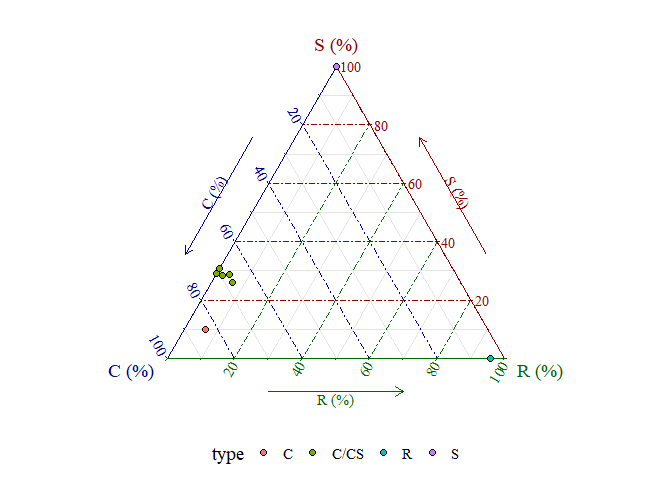

```r
LA <- c(369615.7, 11.8, 55.7, 36061.2, 22391.8, 30068.1, 31059.5, 29895.1)
LDMC <- c(25.2, 39.7, 13.3, 35.5, 33.2, 36.1, 35.2, 34.9)
SLA <- c(17.4, 6.6, 34.1, 14.5, 8.1, 12.1, 9.4, 10.9)
traits <- data.frame(LA, LDMC, SLA)
result <- CSR(data = traits)
CSR_plot(data=result)
```

### LHS Strategy

The LHS strategy analysis function helps you analyze plant strategies based on the LHS (Leaf-Height-Seed) theory:

```r
data(PFF)
pff <- PFF[, c("SLA", "Height", "SeedMass")]
result <- LHS(pff)
head(result)
```

```
##   SLA Height SeedMass LHS_strategy
## 1   8     14    0.140        S-S-S
## 2  20     12    2.530        L-S-L
## 3   9     26    0.388        S-L-S
## 4  16     44    5.896        L-L-L
## 5  31      1    0.128        L-S-S
## 6  13      2    0.061        S-S-S
```

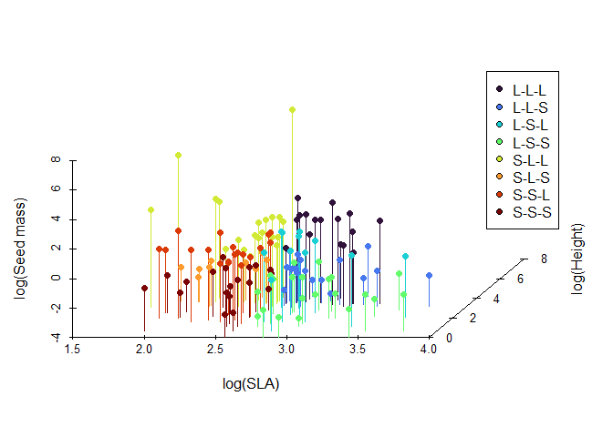

```r
LHS_plot(result)
```

```r
LHS_strategy_scheme()
```

```
##    type                                                         strategy
## 1 L-L-L           Rapid growth, strong survivability and competitiveness
## 2 L-L-S      Rapid growth, strong survivability and weak competitiveness
## 3 L-S-L Rapid growth, long-distance dispersal and strong competitiveness
## 4 L-S-S   Rapid growth, long-distance dispersal and weak competitiveness
## 5 S-L-L            Slow growth, strong survivability and competitiveness
## 6 S-L-S       Slow growth, strong survivability and weak competitiveness
## 7 S-S-L  Slow growth, long-distance dispersal and strong competitiveness
## 8 S-S-S    Slow growth, long-distance dispersal and weak competitiveness
```

### Niche Periodicity Table

The niche periodicity table analysis function allows you to visualize the distribution of plant traits across different environmental gradients:

```r
data(PFF)
PFF[,3:20] <- log(PFF[,3:20])
PFF <- na.omit(PFF)
traits_dimension <-list(
  grow = c("SLA","Leaf_area","LDMC","SRL","Leaf_Nmass","Leaf_Pmass","Root_Nmass"),
  survive = c("Height","Leaf_Cmass","Root_Cmass","Leaf_CN","Leaf_NP","Leaf_CP","Root_CN"),
  reproductive = c("SeedMass","FltDate","FltDur"))
npt_result <- NPT(data = PFF, dimension = traits_dimension)
npt_result
```

```
## $PCA_first
##              pc1_percent pc1_major_eigenvector pc2_percent
## grow            61.05240             Leaf_area   15.460864
## survive         48.69647                Height   35.885156
## reproductive    95.17637              SeedMass    4.170238
##              pc2_major_eigenvector
## grow                    Leaf_Pmass
## survive                    Leaf_CP
## reproductive                FltDur
##
## $PCA_second
##                         PC1         PC2
## pc1.grow         -0.4421504  0.29926226
## pc2.grow         -0.2646905 -0.47439875
## pc1.survive      -0.4575448  0.19461245
## pc2.survive       0.1929222  0.51719484
## pc1.reproductive -0.5001406  0.02455148
## pc2.reproductive  0.1055980  0.07855093
##
## $result
## Call: rda(X = P)
##
## -- Model Summary --
##
##               Inertia Rank
## Total         0.05941
## Unconstrained 0.05941    6
##
## Inertia is variance
##
## -- Eigenvalues --
##
## Eigenvalues for unconstrained axes:
##      PC1      PC2      PC3      PC4      PC5      PC6
## 0.018757 0.015200 0.011163 0.005438 0.004725 0.004123
```

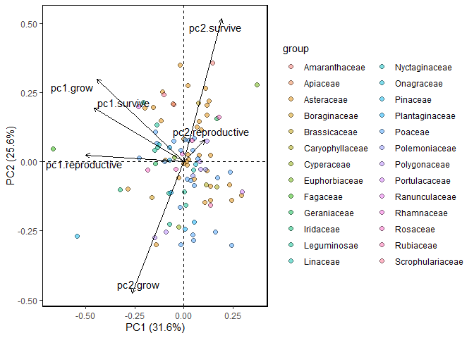

```r
NPT_plot(npt_result$result, PFF$family)
```

### Trait Network

The trait network analysis function helps you explore the relationships between different plant traits:

```r
data(WH)
WH <- WH[,4:23]
Tn_result <- TN(traits_matrix = WH, rThres = 0.2, pThres = 0.05)
TN_metrics(Tn_result)
```

```
## $node
##         degree  closeness betweenness clustering_coefficient
## Height       8 0.07812990          46              0.3928571
## ShDM         7 0.06930042           9              0.5238095
## Depth        5 0.06437432           9              0.2000000
## RBD          5 0.05927325          17              0.6000000
## RBL          5 0.05689054           0              0.9000000
## RD_AR        6 0.06172718          11              0.4666667
## RD_LR        4 0.06175661           9              0.1666667
## RDMC_AR      7 0.06546688          12              0.3809524
## RDMC_LR      5 0.05504807           9              0.3000000
## SRL_AR       9 0.07514325          24              0.4166667
## SRL_LR       4 0.05941401           4              0.5000000
## RP_AR        2 0.04878005           0              0.0000000
## RP_LR        1 0.03983178           0                    NaN
## LT           3 0.04963639           9              0.3333333
## LDMC         4 0.05695803           3              0.6666667
## SLA          3 0.04582727           7              0.3333333
## LP           2 0.03456032           0              1.0000000
## RhDMC        2 0.04584791           0              1.0000000
## LSI          6 0.06764199          23              0.4000000
##
## $global
##   edge_density diameter avg_path_length avg_clustering_coefficient modularity
## 1    0.2573099  2.23915        1.005394                  0.4433498  0.3055269
```

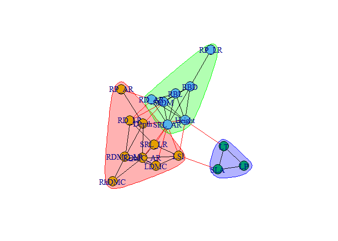

```r
TN_plot(Tn_result, style = 1)
```